# Covid-19 Modeling using SIR model

On 30 January 2020, the WHO announces the outbreak of COVID-19 as a public health emergency of international concern (PHEIC) by the WHO. The SIR model is applied to the COVID-19 dataset to predict the number of infection and recovery from COVID-19 for 150 days in the future.

```r
library(stats4)
library(dplyr)
```

```r
library(ggplot2)
library(reshape2)

dataframe = read.csv("C:/Users/Amani/Downloads/covid_19_data.csv")
```

- Starting with produce a summary of the imported data
- Then cleaning the date format for observation
- creating a time series of that data, divided into infected and recovered data.

```r
#Produce a summary of the imported data, then clean the observation date format and
#build a timeseries of that data, separated into infected and recovered.

summary(dataframe)
```

```
##       SNo          ObservationDate                       Province.State
##  Min.   :    1   04/06/2020:  320                               :6202
##  1st Qu.: 3223   04/07/2020:  320   Diamond Princess cruise ship: 102
##  Median : 6445   04/05/2020:  319   Gansu                       :  79
##  Mean   : 6445   04/04/2020:  316   Hebei                       :  79
##  3rd Qu.: 9667   04/02/2020:  315   Anhui                       :  77
##  Max.   :12889   04/03/2020:  315   Beijing                     :  77
##                  (Other)   :10984   (Other)                     :6273
##         Country.Region              Last.Update      Confirmed
##  US            :2556   3/8/20 5:31        :  921   Min.   :     0
##  Mainland China:2385   2020-04-07 23:11:31:  320   1st Qu.:     5
##  Canada        : 488   4/6/20 9:37        :  320   Median :    49
##  Australia     : 452   2020-04-05 23:13:44:  319   Mean   :  1465
##  France        : 290   2020-04-04 23:41:02:  316   3rd Qu.:   331
##  UK            : 244   2020-04-02 23:32:01:  315   Max.   :141942
##  (Other)       :6474   (Other)            :10378
##      Deaths          Recovered
##  Min.   :    0.0   Min.   :    0.0
##  1st Qu.:    0.0   1st Qu.:    0.0
##  Median :    0.0   Median :    1.0
##  Mean   :   68.5   Mean   :  372.5
##  3rd Qu.:    3.0   3rd Qu.:   22.0
##  Max.   :17127.0   Max.   :64073.0
##
```

```r
dataframe$ObservationDate = as.Date(dataframe$ObservationDate, format = "%m/%d/%y")
timeline = dataframe %>% group_by(ObservationDate) %>% summarize(infecteds=sum(Confirmed), recovereds=sum(Recovered))
```

- visualizing the generated time-series

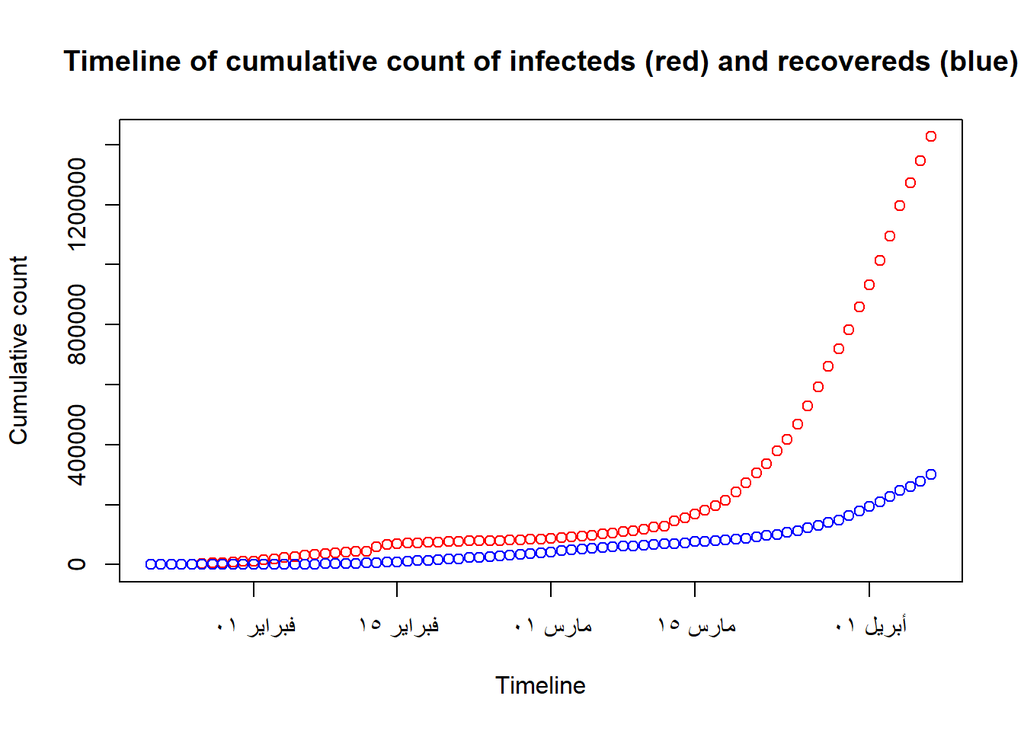

```r
plot(timeline$ObservationDate, timeline$infecteds, xlab = "Timeline", ylab = "Cumulative count", col = "red")
points(timeline$ObservationDate, timeline$recovereds, col = "blue")
title(main = "Timeline of cumulative count of infecteds (red) and recovereds (blue)")
```

there are two sub-waves of infection, which may be the time the coronavirus left China and spread worldwide. The two different growths in the number of reported cases (indicating spread) can be more clearly seen in the graph below.

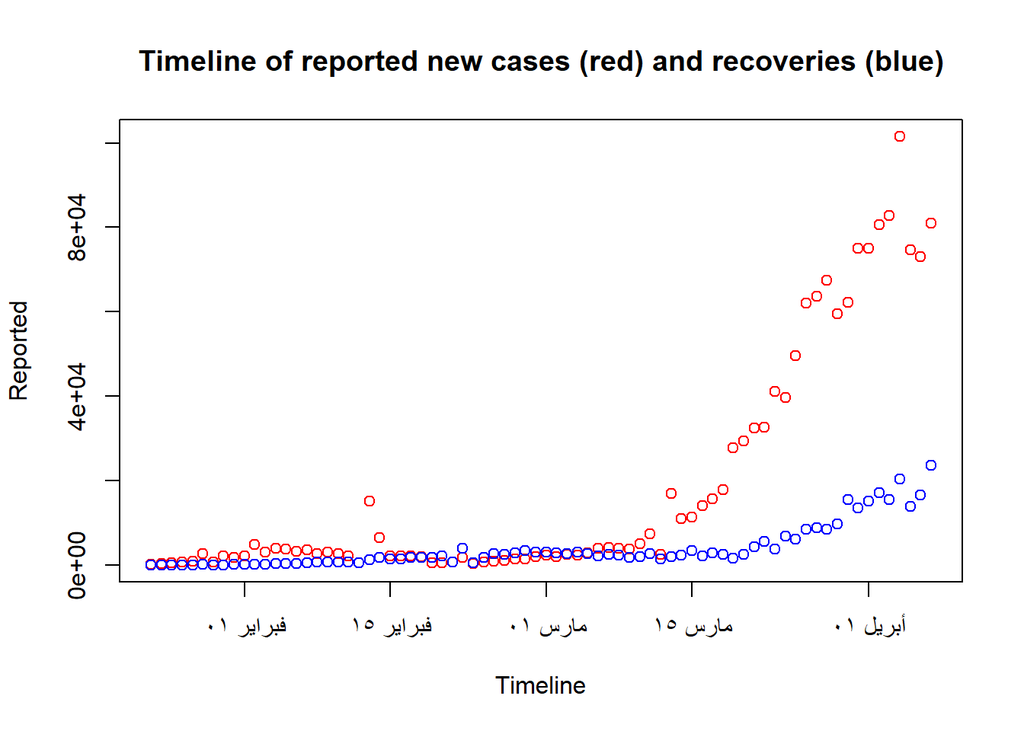

```r
# Calculate the rate of infection
dI = diff(timeline$infecteds)
dt = as.numeric(diff(timeline$ObservationDate))

dIdt = dI / dt

# Calculate the rate of recovery
dRdt = diff(timeline$recovereds) / dt

# Visualize
plot(timeline$ObservationDate[-1], dIdt, xlab = "Timeline", ylab = "Reported", col = "red")
points(timeline$ObservationDate[-1], dRdt, col="blue")
title(main = "Timeline of reported new cases (red) and recoveries (blue)")
```

The first wave is considered to run from the beginning of the dataset until 14 February and the second wave is from 15 February onwards until 4 days before the current date. This cut-off lets us later compare the output of the model with the actual data. At the 95% confidence interval, both the two-sided t-test and the KS-test were conducted with the null hypothesis that the two infection growth rates are the same.

```r
#Comparing the two waves
wave.1 = timeline[timeline$ObservationDate < "2020-02-15",]
wave.2 = timeline[(timeline$ObservationDate >= "2020-02-15") & (timeline$ObservationDate <= Sys.Date()-4),]

# Build the infection rate
infection.rate.linear.modeller = function(in.timeline) {
  dt = as.numeric(diff(in.timeline$ObservationDate))
  dIdt = diff(in.timeline$infecteds) / dt

  model = lm(log(dIdt) ~ in.timeline$ObservationDate[-1])

  result = list("model" = model, "rate" = dIdt)
  return(result)
}


wave.1.results = infection.rate.linear.modeller(wave.1)
wave.2.results = infection.rate.linear.modeller(wave.2)

# t-Test results
print(t.test(log(wave.1.results$rate), log(wave.2.results$rate)))
```

```
##
##  Welch Two Sample t-test
##
## data:  log(wave.1.results$rate) and log(wave.2.results$rate)
## t = -4.2478, df = 61.499, p-value = 7.435e-05
## alternative hypothesis: true difference in means is not equal to 0
## 95 percent confidence interval:
##  -2.1298513 -0.7665925
## sample estimates:
## mean of x mean of y
##  7.469233  8.917454
```

```r
# KS-Test results
print(ks.test(log(wave.1.results$rate), log(wave.2.results$rate)))
```

```
##
##  Two-sample Kolmogorov-Smirnov test
##
## data:  log(wave.1.results$rate) and log(wave.2.results$rate)
## D = 0.44632, p-value = 0.002326
## alternative hypothesis: two-sided
```

The three equations are:

dS/dt = - b SI/N

dR/dt = cI

dI/dt = b SI/N - cI

As there is no data for the susceptible column, this data was obtained based on the number of infected and recovered using the condition above. I interpreted the infected column to also include people who are infected but who have recovered so that they are removed before calculating S.

```r
#The SIR Model
N = 2e6 # The assumption!

# Create the I and R columns out of the second wave
wave.2.I = wave.2$infecteds - wave.2$recovereds
wave.2.R = wave.2$recovereds

# Applying condition N = S+I+R
wave.2.S = N - wave.2.I - wave.2.R
```

based on the first equation we fit the growth data into a linear regression. There is no (linear) correlation, under the null hypothesis.

```r
#Using the first equation, we fit a linear regressio
x = wave.2.I * wave.2.S / N
x = x[-1]
y = diff(wave.2.S) / as.numeric(diff(wave.2$ObservationDate))
b.reg = lm(y ~ x + 0)

rm(x)
rm(y)

# Show the regression summary and save the coefficient
print(summary(b.reg))
```

```
##
## Call:
## lm(formula = y ~ x + 0)
##
## Residuals:
##    Min     1Q Median     3Q    Max
## -29589   1433   4992   8235  10284
##
## Coefficients:
##    Estimate Std. Error t value Pr(>|t|)
## x -0.188348   0.005728  -32.88   <2e-16 ***
## ---
## Signif. codes:  0 '***' 0.001 '**' 0.01 '*' 0.05 '.' 0.1 ' ' 1
##
## Residual standard error: 7630 on 48 degrees of freedom
## Multiple R-squared:  0.9575, Adjusted R-squared:  0.9566
## F-statistic:  1081 on 1 and 48 DF,  p-value: < 2.2e-16
```

```r
b = -as.numeric(coef(b.reg))


#we do the same for the recovery based on the second equation.
# dR/dt = c*I
y = diff(wave.2.R) / as.numeric(diff(wave.2$ObservationDate))
x = wave.2.I[-1]
c.reg = lm(y ~ x + 0)

# Clean
rm(x)
rm(y)

print(summary(c.reg))
```

```
##
## Call:
## lm(formula = y ~ x + 0)
##
## Residuals:
##      Min       1Q   Median       3Q      Max
## -2083.96   -40.67   682.92  1531.75  2975.08
##
## Coefficients:
##    Estimate Std. Error t value Pr(>|t|)
## x 0.0202466  0.0006067   33.37   <2e-16 ***
## ---
## Signif. codes:  0 '***' 0.001 '**' 0.01 '*' 0.05 '.' 0.1 ' ' 1
##
## Residual standard error: 1393 on 48 degrees of freedom
## Multiple R-squared:  0.9587, Adjusted R-squared:  0.9578
## F-statistic:  1114 on 1 and 48 DF,  p-value: < 2.2e-16
```

```r
c = as.numeric(coef(c.reg))
```

so the c and b are determined which means we have the necessary coefficients to build the model. That is where the last equation will come in. the model is building on the already present data, predicting 150 days in the future.

```r
#dI/dt = b*S*I/N - c*I

n.sim = 150 # Number of days to prognose
position = length(wave.2$ObservationDate)
S = c(wave.2.S, rep(0, n.sim))
I = c(wave.2.I, rep(0, n.sim))
R = c(wave.2.R, rep(0, n.sim))
new.len = length(S)

# Expand the dates column
dates = c(wave.2$ObservationDate, rep(0, n.sim))



for(m in position+1:n.sim) {
  S.change = -b*S[m-1]*I[m-1] / N
  S[m] = max(min(S[m-1] + S.change, N), 0)

  R.change = c*I[m-1]
  R[m] = min(R[m-1] + R.change, N)

  I.change = b*S[m-1]*I[m-1] / N - c*I[m-1]
  I[m] = max(I[m-1] + I.change, 0)

  dates[m] = dates[m-1] + 1
}
```

The graph below shows the output of the SIR model along with the data.

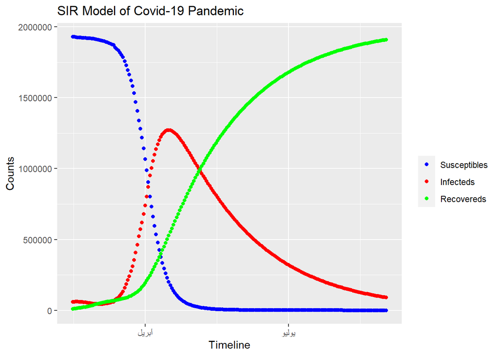

```r
# Tidy up the results and visualize
results.sir.model = data.frame(
  Dates = dates,
  Susceptibles = S,
  Infecteds = I,
  Recovereds = R
)

#plot
sir.melt = melt(results.sir.model, id='Dates')
sir.plot = ggplot(data=sir.melt, aes(x=Dates, y=value, color=variable)) + geom_point() + labs(title="SIR Model of Covid-19 Pandemic", x="Timeline", y="Counts")
sir.plot = sir.plot + scale_color_manual(name = "", values = c('blue', 'red', 'green'))
sir.plot
```

```r
#max number
results.sir.model[results.sir.model$Infecteds>=max(results.sir.model$Infecteds),]
```

```
##         Dates Susceptibles Infecteds Recovereds
## 62 2020-04-16     201266.5   1271838   526895.6
```

```r
view.df = results.sir.model[(results.sir.model$Dates>=Sys.Date()-5) & (results.sir.model$Dates<=Sys.Date()+5),]

print(view.df)
```

```
##         Dates Susceptibles Infecteds Recovereds
## 49 2020-04-03     904083.0    870121   225796.0
## 50 2020-04-04     802595.0    951253   246152.0
## 51 2020-04-05     730695.8   1003893   265411.6
## 52 2020-04-06     661615.3   1052648   285737.0
## 53 2020-04-07     596027.9   1096923   307049.5
## 54 2020-04-08     534457.2   1136284   329258.4
## 55 2020-04-09     477265.7   1170470   352264.3
## 56 2020-04-10     424657.6   1199380   375962.3
## 57 2020-04-11     376692.3   1223062   400245.6
## 58 2020-04-12     333304.6   1241687   425008.4
## 59 2020-04-13     294329.7   1255522   450148.3
```

It is important to note that the recovery rate tends to be pretty reliable in the short term, at least, while the infected rate causes underestimation when this model was previously tested. With more data available due to disease progression, the predictions will get better.

```r
actual.df = timeline[(timeline$ObservationDate >= "2020-02-15"),]

colnames(view.df) = c("Dates", "Predicted_Susceptibles", "Predicted_Infecteds", "Predicted_Recovereds")
colnames(actual.df) = c("Dates", "Actual_Infecteds", "Actual_Recovereds")


# The Actual.Infecteds column is actually the total cases, so subtraction of recovereds is needed
actual.df$Actual_Infecteds = actual.df$Actual_Infecteds - actual.df$Actual_Recovereds

# Drop the susceptibles prediction as this is the artificial variable, for which there is no comparison
view.df = view.df[c("Dates", "Predicted_Infecteds", "Predicted_Recovereds")]
view.df = view.df[view.df$Dates > Sys.Date()-5,]

merged = merge(view.df, actual.df)
print(merged)
```

```
##        Dates Predicted_Infecteds Predicted_Recovereds Actual_Infecteds
## 1 2020-04-04              951253             246152.0           951253
## 2 2020-04-05             1003893             265411.6          1012103
## 3 2020-04-06             1052648             285737.0          1068586
## 4 2020-04-07             1096923             307049.5          1126042
##   Actual_Recovereds
## 1            246152
## 2            260012
## 3            276515
## 4            300054
```